# Zymbo Mock Community Data Analysis (16S rRNA gene amplicon sequencing) using LDA-STAN (Variational Bayes)

Pratheepa Jeganathan

May 16, 2019

We have 10 negative control samples and serial dilution of ZymoBIOMICS® Microbial Community Standard.

Looking at the DADA2 pipeline ASVs 2, 3, 4, 5, 6, 7, 8, 11, 17, 37, 22 are in the ZymoBIOMICS® Microbial Community Standard.

Loading packages

```r
library(phyloseq)
library(ggplot2)
library(magrittr)
library(dplyr)
library(reshape2)
library(rstan)
```

### Read phyloseq and exploratory analysis

```r
ps = readRDS("./Data/ps_zymo.rds")
if(dim(otu_table(ps))[1]!=ntaxa(ps)){
  otu_table(ps) = t(otu_table(ps))
  }
```

change order of sample names

```r
ncont = paste0("NegativeControl.", seq(1, 10))
stan = paste0("Standard.Dilution.1.",c(1, 6, 36, 216, 1296, 7776, 46656, 279936))

sample_data(ps)$Name = factor(sample_data(ps)$Name, levels = c(ncont,stan))

sample_names(ps) = as.character(sample_data(ps)$Name)
```

Store sequence variants, ASVs, ASV.genus, ASV.genus.species

```r
ASV = as.character(paste0("ASV_", seq(1,ntaxa(ps))))

ASV.Genus = paste0("ASV_", seq(1,ntaxa(ps)), "_", as.character(tax_table(ps)[,6]))

ASV.Genus.Species = paste0(ASV, "_", as.character(tax_table(ps)[,6]), "_", as.character(tax_table(ps)[,7]))

df.ASV = data.frame(seq.variant = taxa_names(ps), ASV = ASV, ASV.Genus = ASV.Genus, ASV.Genus.Species = ASV.Genus.Species)
```

```r
taxa_names(ps) = df.ASV$ASV.Genus.Species
```

### Microbial composition of the ZymoBIOMICS® Microbial Community Standard (Zymo Research, Irvine, CA) measured

True ASVs at genus level

```r
# true.com.ASV = taxa_names(ps)[which(tax_table(ps)[,6] %in% c("Bacillus","Listeria","Staphylococcus", "Lactobacillus", "Escherichia/Shigella", "Enterococcus", "Salmonella", "Pseudomonas"))]
true.com.ASV = taxa_names(ps)[c(2:8,11,17,37,22)]
ps.true = transform_sample_counts(ps, function(OTU) OTU/sum(OTU))
ps.true = prune_taxa(true.com.ASV, ps.true)
ps.true
```

```
## phyloseq-class experiment-level object
## otu_table()   OTU Table:         [ 11 taxa and 18 samples ]
## sample_data() Sample Data:       [ 18 samples by 4 sample variables ]
## tax_table()   Taxonomy Table:    [ 11 taxa by 7 taxonomic ranks ]
```

### Create a list of true ASVs in each diluted sample

```r
true.com.ASV = taxa_names(ps)[c(2:8,11,17,22,37)]
# true.com.ASV = taxa_names(ps)[which((tax_table(ps)[,6] %in% c("Bacillus","Listeria","Staphylococcus", "Lactobacillus", "Escherichia/Shigella", "Enterococcus", "Salmonella", "Pseudomonas")))]

# true.com.ASV = taxa_names(ps)[which((tax_table(ps)[,6] %in% c("Bacillus","Listeria","Staphylococcus", "Lactobacillus", "Escherichia/Shigella", "Enterococcus", "Salmonella", "Pseudomonas"))&(!is.na(tax_table(ps)[,7])))]

diluted.sample.names = sample_names(ps)[3:10]

trueSeq = function(sample.name, true.com.ASV){
  df.sample.i = data.frame(ot = otu_table(ps)[, sample.name])
  names(df.sample.i) = "ot"
  df.sample.i = mutate(df.sample.i, ASV = rownames(df.sample.i))
  df.sample.i.true.seq = filter(df.sample.i, (ot > 0) & (as.character(ASV) %in% true.com.ASV))
  true.seq.sample.i = as.character(df.sample.i.true.seq$ASV)
  return(true.seq.sample.i)
}


true.seq.all.samples = lapply(diluted.sample.names, FUN = trueSeq, true.com.ASV = true.com.ASV)

##true.seq.all.samples
```

Number of true ASVs in each dilution series sample

```r
number.of.true.ASVs = lapply(true.seq.all.samples, function(x) {length(x)})
```

Number of unique true ASV in all samples

```r
number.of.unique.ASVs.in.all.samples = length(unique(unlist(true.seq.all.samples)))
```

### Check the percentage of eleven ASVs in each dilution series sample

```r
ps.prop = transform_sample_counts(ps, function(otu) otu/sum(otu)*100)
ps.true = prune_taxa(unique(unlist(true.seq.all.samples)), ps)
ps.prop.true = prune_taxa(taxa_names(ps.true), ps.prop)
dt = otu_table(subset_samples(ps.prop.true,
  SampleType == "Standard")) %>% data.frame()
colnames(dt) = sample_data(subset_samples(ps.prop.true,
  SampleType == "Standard"))$Name
#rownames(dt) = df.ASV$ASV.Genus[which(as.character(df.ASV$ASV.Genus.Species) %in% rownames(dt))]
rownames(dt) = df.ASV$ASV.Genus.Species[which(as.character(df.ASV$ASV.Genus.Species) %in% rownames(dt))]
# library(knitr)
# kable(dt)
```

### Adding blocks

We have only one block of samples.

```r
blocks = rep("Set1", nsamples(ps))

sample_data(ps)$block = blocks
```

Identify the species that are not present in at least one `SampleType == Standard` sample and removed them from the phyloseq object. Label these species as contaminants.

```r
ps = prune_taxa(taxa_sums(ps) > 0, ps)
ps.standard = subset_samples(ps, SampleType %in% c("Standard"))
prevTaxaP = apply(otu_table(ps.standard), 1, function(x){sum(x>0)})

Contaminants1 = names(prevTaxaP)[prevTaxaP == 0]
length(Contaminants1)
```

```
## [1] 142
```

```r
ps = prune_taxa(prevTaxaP > 0, ps)
ps
```

```
## phyloseq-class experiment-level object
## otu_table()   OTU Table:         [ 53 taxa and 18 samples ]
## sample_data() Sample Data:       [ 18 samples by 5 sample variables ]
## tax_table()   Taxonomy Table:    [ 53 taxa by 7 taxonomic ranks ]
```

We identifed 142 ASVs not is any dilution series samples and they are classified as contaminants before using BARBI LDA (VB).

See a summary of the `Standard` and `Negative` samples in each block.

```r
table(sample_data(ps)$SampleType, sample_data(ps)$block)
```

```
##
##            Set1
##   Negative   10
##   Standard    8
```

```r
colSums(otu_table(ps))
```

```
##          NegativeControl.1         NegativeControl.10
##                       3268                      11161
##      Standard.Dilution.1.1      Standard.Dilution.1.6
##                      12404                      21843
##     Standard.Dilution.1.36    Standard.Dilution.1.216
##                      14658                      20601
##   Standard.Dilution.1.1296   Standard.Dilution.1.7776
##                      18127                      17779
##  Standard.Dilution.1.46656 Standard.Dilution.1.279936
##                       5184                       8559
##          NegativeControl.2          NegativeControl.3
##                       8311                       6175
##          NegativeControl.4          NegativeControl.5
##                       7237                      12960
##          NegativeControl.6          NegativeControl.7
##                       4905                      11495
##          NegativeControl.8          NegativeControl.9
##                      10482                      13176
```

### Prepare the phyloseq object for the Bayesian inference

We use Bayesian inference to identify contaminants in each block separately to account for the batch-effects of contamination.

Thus, split the phyloseq object into multiple phyloseq objects corresponding to each block, and store the phyloseq objects as a list of phyloseq objects, `psByBlock`.

Select negative control samples from each block and store as a list of phyloseq objects, `psNCbyBlock`.

Select all species that have a prevalence of zero (i.e., have zero reads) in all negative control samples for each block and store as a list of phyloseq objects, `psallzeroInNC`.

Select all plasma samples from each block and store as a list of phyloseq objects, `psPlByBlock`.

```r
source("psBlockResults.R")
psBlockResult = psBlockResults(ps,
  sampleTypeVar = "SampleType", caselevels = c("Standard"), controllevel="Negative", sampleName = "Name", blockVar = "block")

psByBlock = psBlockResult[[1]]
psNCbyBlock = psBlockResult[[2]]
psallzeroInNC = psBlockResult[[3]]
psPlByBlock = psBlockResult[[4]]

# st = sample_names(psByBlock[[1]])[-c(4:10)]
# psByBlock[[1]] = subset_samples(psByBlock[[1]], SampleCode %in% st)
```

## LDA using VB

Each sample is modeled as having a mixture of topics, with each ASV drawn from a topic based on mixing proportions.

### LDA on specimen and control samples

```r
ps = psByBlock[[1]]
short.sample.names = c(paste0("NC.", c(1,10)), paste0("Di.", seq(1,8)), paste0("NC.", seq(2,9)))
sample_names(ps) = short.sample.names
x <- t(get_taxa(ps))
K = 10 # number of topics
dimnames(x) <- NULL
stan_data <- list(
  K = K,
  V = ncol(x),
  D = nrow(x),
  n = x,
  alpha = rep(1, K),
  gamma = rep(0.5, ncol(x))
)
```

```r
start_fit <- Sys.time()

f <- stan_model(file = "lda.stan")

stan_fit <- vb(
  f,
  data = stan_data,
  output_samples = 1000,
  eta = 1,
  adapt_engaged = FALSE
)
cat(sprintf(
  "Finished in %f minutes\n",
  Sys.time() - start_fit, 4)
)
```

```
## Finished in 1.052485 minutes
```

```r
saveRDS(stan_fit, file = "stan_vb_fit.rds")
```

```r
samples <- rstan::extract(stan_fit)
```

### Posterior distirbution of topic in each sample

```r
theta = samples$theta # chain * sample * topic
# find theta distirbution of each topic in each sample
names(theta) = c("theta", "Sample", "Topic")

library(reshape2)
theta.all = melt(theta)
colnames(theta.all) = c("Chain", "Sample", "Topic", "topic.dis")
theta.all$Sample = factor(theta.all$Sample)
levels(theta.all$Sample) = sample_names(ps)
theta.all$Topic = factor(theta.all$Topic)
levels(theta.all$Topic) = c(paste0("Topic_", seq(1,K)))

# add control or dilution series
theta.all =  mutate(theta.all, Group = ifelse(substr(Sample,1,1)=="D","Dilution", "Control"))

theta.all$Group = factor(theta.all$Group)
```

Plot topic distribution in each sample

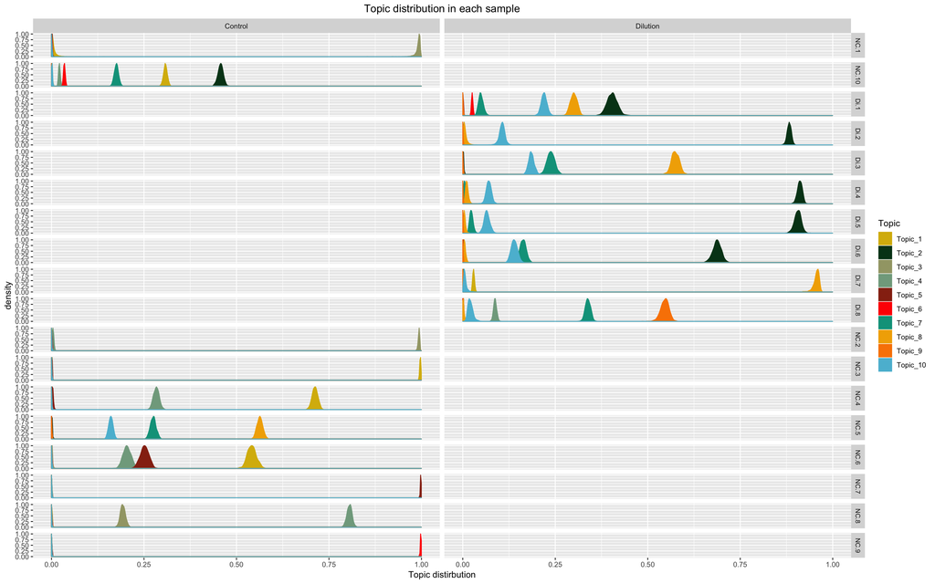

```r
library(RColorBrewer)
library(wesanderson)
col.topic = c(wes_palette("Cavalcanti1", n = 5), wes_palette("Darjeeling1", n = 5))
ggplot() +
  geom_density(data = theta.all ,aes(x = topic.dis, y = ..scaled.., col = Topic, fill=Topic)) +
  facet_grid(Sample ~ Group, scales = "fixed") +
  scale_color_manual(values = col.topic)+
  scale_fill_manual(values = col.topic)+
  ylab("density") +
  xlab("Topic distirbution") +
  ggtitle("Topic distribution in each sample") +
  theme(plot.title = element_text(hjust = 0.5), strip.text.y= element_text(size = 8))
```

### ASV distribution in each topic

```r
beta = samples$beta
beta.all = melt(beta)
colnames(beta.all) = c("Chain", "Topic", "ASV", "ASV.distribution")
beta.all$Topic = factor(beta.all$Topic)
levels(beta.all$Topic) = c(paste0("Topic_", seq(1,K)))
beta.all$ASV = factor(beta.all$ASV)
levels(beta.all$ASV) = df.ASV$ASV.Genus
```

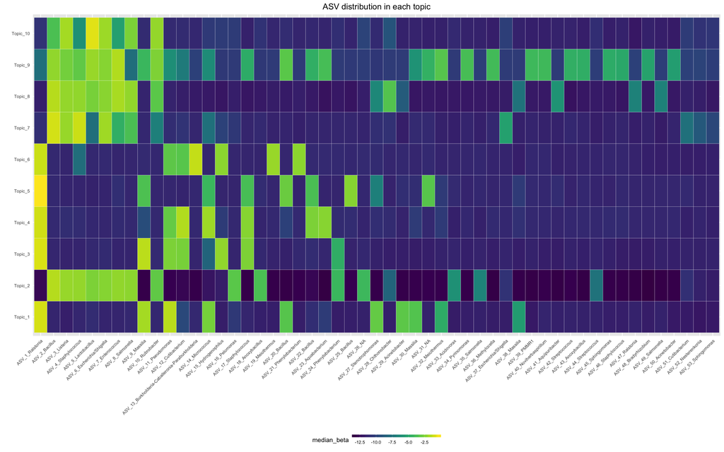

```r
#devtools::install_github("jakobbossek/ggheatmap")
library(ggheatmap)
ggheatmap(
  beta.all %>%
  group_by(Topic, ASV) %>%
  summarise(median_beta = log(median(ASV.distribution, na.rm = TRUE))) %>%
  as.data.frame(),
  id.vars = c("ASV", "Topic"),
  value.name = "median_beta"
) + ggtitle("ASV distribution in each topic") +
  theme(plot.title = element_text(hjust = 0.5))
```

### Can we look at the ASV distribution in each topic in the following way?

```r
### Posterior distirbution of ASV in each topic
beta = samples$beta
beta.all = melt(beta)
colnames(beta.all) = c("Chain", "Topic", "ASV", "ASV.distribution")
beta.all$Topic = factor(beta.all$Topic)
levels(beta.all$Topic) = c(paste0("Topic_", seq(1,K)))
beta.all$ASV = factor(beta.all$ASV)
levels(beta.all$ASV) = df.ASV$ASV.Genus
```

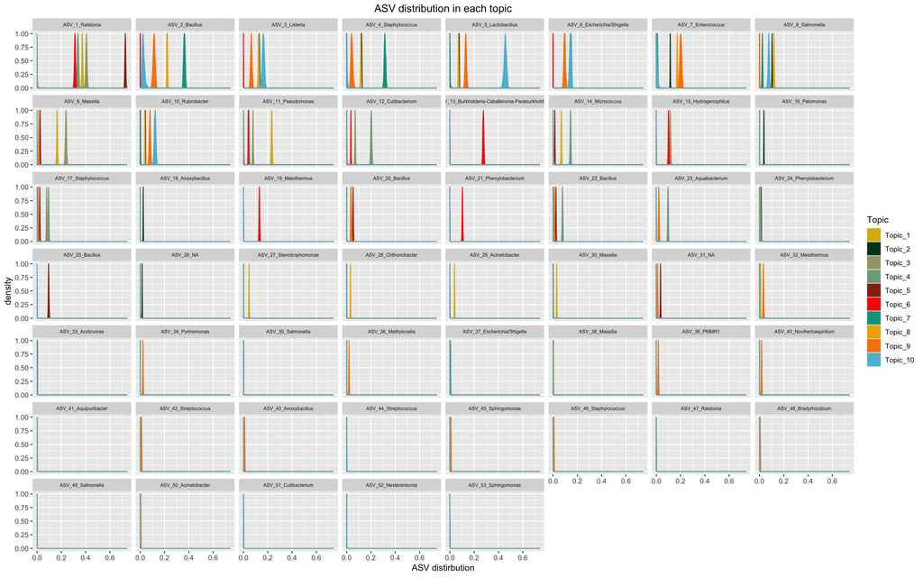

```r
ggplot() +
  geom_density(data = beta.all ,aes(x = ASV.distribution, y = ..scaled.., col = Topic, fill = Topic)) +
  facet_wrap(~ASV, scales = "fixed") +
  scale_color_manual(values = col.topic)+
  scale_fill_manual(values = col.topic) +
  ylab("density") +
  xlab("ASV distirbution") +
  ggtitle("ASV distribution in each topic") +
  theme(plot.title = element_text(hjust = 0.5), strip.text.x= element_text(size = 6))
```